# Project: Investigate important factors associated with appointment show up rate

- Introduction
- Data Wrangling
- Exploratory Data Analysis
- Conclusions

## Introduction

> This no-show appointment dataset collects information from 100k medical appointments in Brazil and is focused on the question of whether or not patients show up for their appointments. A number of characteristics about the patient are included in each row. In this report, we are trying to investigate the important factors associated with the show up rate of appointments. Therefore, we are going to answer the following questions:
> 1. Is gender of a patient affecting his/her show up rate of appointments？
> 2. Is age of a patient affecting his/her show up rate of appointments？
> 3. Is the show up rate affected by whether the patient is enrolled in Brasilian welfare program?
> 4. Is the show up rate affected by whether the patient is an alcoholic?
> 5. Is the show up rate affected by whether the appointment is on weekend or weekdays, or any specific day of a week?
> 6. Is the show up rate affected by whether a message is received?
> 7. Is the show up rate affected by whether the patients are disabled?
> 8. Is the show up rate affected by whether the scheduled day is same or different with the appointment day?

> By answering these questions, we will have a better understanding of the dataset.

### Import statements for packages

```python
#import statements for packages that will be used

import pandas as pd
import numpy as np
import matplotlib.pyplot as plt
import seaborn as sns
plt.style.use('fivethirtyeight')

% matplotlib inline
```

## Data Wrangling

### General Properties:

```python
# load the dataset and print out 5 lines

df = pd.read_csv('noshowappointments-kagglev2-may-2016.csv')
df.head(5)
```

|  | PatientId | AppointmentID | Gender | ScheduledDay | AppointmentDay | Age | Neighbourhood | Scholarship | Hipertension | Diabetes | Alcoholism | Handcap | SMS_received | No-show |
| --- | --- | --- | --- | --- | --- | --- | --- | --- | --- | --- | --- | --- | --- | --- |
| 0 | 2.987250e+13 | 5642903 | F | 2016-04-29T18:38:08Z | 2016-04-29T00:00:00Z | 62 | JARDIM DA PENHA | 0 | 1 | 0 | 0 | 0 | 0 | No |
| 1 | 5.589978e+14 | 5642503 | M | 2016-04-29T16:08:27Z | 2016-04-29T00:00:00Z | 56 | JARDIM DA PENHA | 0 | 0 | 0 | 0 | 0 | 0 | No |
| 2 | 4.262962e+12 | 5642549 | F | 2016-04-29T16:19:04Z | 2016-04-29T00:00:00Z | 62 | MATA DA PRAIA | 0 | 0 | 0 | 0 | 0 | 0 | No |
| 3 | 8.679512e+11 | 5642828 | F | 2016-04-29T17:29:31Z | 2016-04-29T00:00:00Z | 8 | PONTAL DE CAMBURI | 0 | 0 | 0 | 0 | 0 | 0 | No |
| 4 | 8.841186e+12 | 5642494 | F | 2016-04-29T16:07:23Z | 2016-04-29T00:00:00Z | 56 | JARDIM DA PENHA | 0 | 1 | 1 | 0 | 0 | 0 | No |

```python
# check how many rows and columns in total

df.shape
```

```
(110527, 14)
```

```python
# check if there is missing data (there is no missing data)

df.info()
```

```
<class 'pandas.core.frame.DataFrame'>
RangeIndex: 110527 entries, 0 to 110526
Data columns (total 14 columns):
PatientId         110527 non-null float64
AppointmentID     110527 non-null int64
Gender            110527 non-null object
ScheduledDay      110527 non-null object
AppointmentDay    110527 non-null object
Age               110527 non-null int64
Neighbourhood     110527 non-null object
Scholarship       110527 non-null int64
Hipertension      110527 non-null int64
Diabetes          110527 non-null int64
Alcoholism        110527 non-null int64
Handcap           110527 non-null int64
SMS_received      110527 non-null int64
No-show           110527 non-null object
dtypes: float64(1), int64(8), object(5)
memory usage: 11.8+ MB
```

```python
# check if there is duplicated data (there are no duplicats)

sum(df.duplicated())
```

```
0
```

### Rename the column names to be consistent and easy to process.

```python
# change all the column names to lower case to be consistent
# load the first 2 lines to confirm the change of the columns names

df.columns = map(str.lower, df.columns)
df.head(2)
```

|  | patientid | appointmentid | gender | scheduledday | appointmentday | age | neighbourhood | scholarship | hipertension | diabetes | alcoholism | handcap | sms_received | no-show |
| --- | --- | --- | --- | --- | --- | --- | --- | --- | --- | --- | --- | --- | --- | --- |
| 0 | 2.987250e+13 | 5642903 | F | 2016-04-29T18:38:08Z | 2016-04-29T00:00:00Z | 62 | JARDIM DA PENHA | 0 | 1 | 0 | 0 | 0 | 0 | No |
| 1 | 5.589978e+14 | 5642503 | M | 2016-04-29T16:08:27Z | 2016-04-29T00:00:00Z | 56 | JARDIM DA PENHA | 0 | 0 | 0 | 0 | 0 | 0 | No |

```python
# change the column name "no-show" to "no_show", otherwise it is difficult to deal with this column.
# load the first 2 lines to confirm the change of the name.

df.rename(columns={'no-show':'no_show'},inplace=True)
df.head(2)
```

|  | patientid | appointmentid | gender | scheduledday | appointmentday | age | neighbourhood | scholarship | hipertension | diabetes | alcoholism | handcap | sms_received | no_show |
| --- | --- | --- | --- | --- | --- | --- | --- | --- | --- | --- | --- | --- | --- | --- |
| 0 | 2.987250e+13 | 5642903 | F | 2016-04-29T18:38:08Z | 2016-04-29T00:00:00Z | 62 | JARDIM DA PENHA | 0 | 1 | 0 | 0 | 0 | 0 | No |
| 1 | 5.589978e+14 | 5642503 | M | 2016-04-29T16:08:27Z | 2016-04-29T00:00:00Z | 56 | JARDIM DA PENHA | 0 | 0 | 0 | 0 | 0 | 0 | No |

```python
# change the value "Yes" to "0" indicating not show up; change the value "No" to "1" indicating show up;
# count the value to confirm the values have been successfully changed

df['no_show'] = df['no_show'].str.lower().replace({'yes': 0, 'no': 1})
df['no_show'].value_counts()
```

```
1    88208
0    22319
Name: no_show, dtype: int64
```

```python
# have an overview of the data

df.describe()
```

|  | patientid | appointmentid | age | scholarship | hipertension | diabetes | alcoholism | handcap | sms_received | no_show |
| --- | --- | --- | --- | --- | --- | --- | --- | --- | --- | --- |
| count | 1.105270e+05 | 1.105270e+05 | 110527.000000 | 110527.000000 | 110527.000000 | 110527.000000 | 110527.000000 | 110527.000000 | 110527.000000 | 110527.000000 |
| mean | 1.474963e+14 | 5.675305e+06 | 37.088874 | 0.098266 | 0.197246 | 0.071865 | 0.030400 | 0.022248 | 0.321026 | 0.798067 |
| std | 2.560949e+14 | 7.129575e+04 | 23.110205 | 0.297675 | 0.397921 | 0.258265 | 0.171686 | 0.161543 | 0.466873 | 0.401444 |
| min | 3.921784e+04 | 5.030230e+06 | -1.000000 | 0.000000 | 0.000000 | 0.000000 | 0.000000 | 0.000000 | 0.000000 | 0.000000 |
| 25% | 4.172614e+12 | 5.640286e+06 | 18.000000 | 0.000000 | 0.000000 | 0.000000 | 0.000000 | 0.000000 | 0.000000 | 1.000000 |
| 50% | 3.173184e+13 | 5.680573e+06 | 37.000000 | 0.000000 | 0.000000 | 0.000000 | 0.000000 | 0.000000 | 0.000000 | 1.000000 |
| 75% | 9.439172e+13 | 5.725524e+06 | 55.000000 | 0.000000 | 0.000000 | 0.000000 | 0.000000 | 0.000000 | 1.000000 | 1.000000 |
| max | 9.999816e+14 | 5.790484e+06 | 115.000000 | 1.000000 | 1.000000 | 1.000000 | 1.000000 | 4.000000 | 1.000000 | 1.000000 |

```python
# age=-1 doesn't make sense, so this row needs to be dropped
# find the row with age==-1

df[df['age'] == -1]
```

|  | patientid | appointmentid | gender | scheduledday | appointmentday | age | neighbourhood | scholarship | hipertension | diabetes | alcoholism | handcap | sms_received | no_show |
| --- | --- | --- | --- | --- | --- | --- | --- | --- | --- | --- | --- | --- | --- | --- |
| 99832 | 4.659432e+14 | 5775010 | F | 2016-06-06T08:58:13Z | 2016-06-06T00:00:00Z | -1 | ROMÃO | 0 | 0 | 0 | 0 | 0 | 0 | 1 |

```python
# drop this row and confirm

df.drop(df.index[99832], inplace=True)
df.shape
```

```
(110526, 14)
```

```python
# the 'handcap' is outstanding since the max is "4", so we have a closer look at the value counts

df['handcap'].value_counts()
```

```
0    108285
1      2042
2       183
3        13
4         3
Name: handcap, dtype: int64
```

```python
# the values of handcap should be "0" or "1", however, there are values form "0" to "4". The values of "1" to "4"
# may indicate the severity of the disability or just simply typos. To deal with it, I decided to change the values
# "2" to "4" to "1".

df.replace({'handcap': [2,3,4]}, 1, inplace=True)
df['handcap'].value_counts()
```

```
0    108285
1      2241
Name: handcap, dtype: int64
```

```python
# have an overview of the updated dataset.

df.describe()
```

|  | patientid | appointmentid | age | scholarship | hipertension | diabetes | alcoholism | handcap | sms_received | no_show |
| --- | --- | --- | --- | --- | --- | --- | --- | --- | --- | --- |
| count | 1.105260e+05 | 1.105260e+05 | 110526.000000 | 110526.000000 | 110526.000000 | 110526.000000 | 110526.000000 | 110526.000000 | 110526.000000 | 110526.000000 |
| mean | 1.474934e+14 | 5.675304e+06 | 37.089219 | 0.098266 | 0.197248 | 0.071865 | 0.030400 | 0.020276 | 0.321029 | 0.798066 |
| std | 2.560943e+14 | 7.129544e+04 | 23.110026 | 0.297676 | 0.397923 | 0.258266 | 0.171686 | 0.140943 | 0.466874 | 0.401445 |
| min | 3.921784e+04 | 5.030230e+06 | 0.000000 | 0.000000 | 0.000000 | 0.000000 | 0.000000 | 0.000000 | 0.000000 | 0.000000 |
| 25% | 4.172536e+12 | 5.640285e+06 | 18.000000 | 0.000000 | 0.000000 | 0.000000 | 0.000000 | 0.000000 | 0.000000 | 1.000000 |
| 50% | 3.173184e+13 | 5.680572e+06 | 37.000000 | 0.000000 | 0.000000 | 0.000000 | 0.000000 | 0.000000 | 0.000000 | 1.000000 |
| 75% | 9.438963e+13 | 5.725523e+06 | 55.000000 | 0.000000 | 0.000000 | 0.000000 | 0.000000 | 0.000000 | 1.000000 | 1.000000 |
| max | 9.999816e+14 | 5.790484e+06 | 115.000000 | 1.000000 | 1.000000 | 1.000000 | 1.000000 | 1.000000 | 1.000000 | 1.000000 |

```python
# since the appointment day only contains the information of the date, and the time of the schedule does not
# provide extra information, it can be removed to be consistent

df['scheduledday'] = df['scheduledday'].str[:10]
```

```python
# change the dtype of the scheduledday and appointmentday to datetime to make later analysis easier
# load the first 2 row to confirm the changes

df['scheduledday'] = pd.to_datetime(df['scheduledday'])
df['appointmentday'] = pd.to_datetime(df['appointmentday'])
df.head(2)
```

|  | patientid | appointmentid | gender | scheduledday | appointmentday | age | neighbourhood | scholarship | hipertension | diabetes | alcoholism | handcap | sms_received | no_show |
| --- | --- | --- | --- | --- | --- | --- | --- | --- | --- | --- | --- | --- | --- | --- |
| 0 | 2.987250e+13 | 5642903 | F | 2016-04-29 | 2016-04-29 | 62 | JARDIM DA PENHA | 0 | 1 | 0 | 0 | 0 | 0 | 1 |
| 1 | 5.589978e+14 | 5642503 | M | 2016-04-29 | 2016-04-29 | 56 | JARDIM DA PENHA | 0 | 0 | 0 | 0 | 0 | 0 | 1 |

## Exploratory Data Analysis

.

### Visualize the show-up rate:

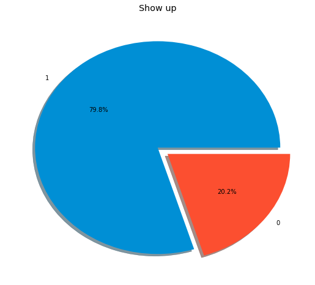

```python
# the pie chasrt shows that the show-up rate of all the appointment is 79.8%

f,ax=plt.subplots(1,figsize=(8,8))
df['no_show'].value_counts().plot.pie(explode=[0,0.1],autopct='%1.1f%%',ax=ax,shadow=True)
ax.set_title('Show up')
ax.set_ylabel('')
plt.show()
```

### 1. To investigate whether the gender of a patient can affect his/her showup-rate:¶

```python
# calculate the show-up rate of different genders

df.groupby('gender')['no_show'].mean()
```

```
gender
F    0.796851
M    0.800321
Name: no_show, dtype: float64
```

### Since the show-up rate of female and male appear to be very similar, the gender does not seem to be an important factor for to follow up with visualization.

### 2. To investigate whether the age of a patient can affect his/her showup-rate:

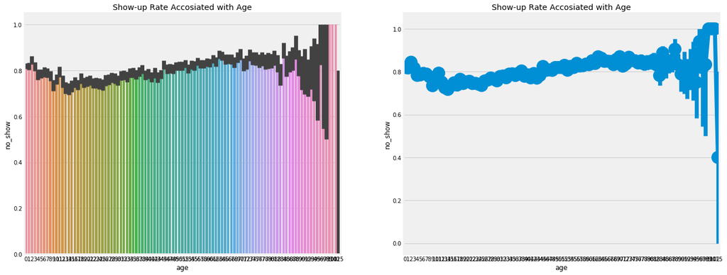

```python
# Bar chart and line chart were drawn to show the relationship between age and show-up rate

f,ax=plt.subplots(1,2,figsize=(20,8))
sns.barplot('age','no_show',data=df,ax=ax[0])
ax[0].set_title('Show-up Rate Accosiated with Age')
sns.factorplot('age','no_show',data=df,ax=ax[1])
ax[1].set_title('Show-up Rate Accosiated with Age')
plt.close(2)
plt.show()
```

```python
# since the age has values, it requires age groups to replace the individual ages
# first, here is an overview of all the ages of the patients

df['age'].describe()
```

```
count    110526.000000
mean         37.089219
std          23.110026
min           0.000000
25%          18.000000
50%          37.000000
75%          55.000000
max         115.000000
Name: age, dtype: float64
```

```python
# group the patients to 3 different age groups according to the age quantification data
# calculate the show-up rate of different age groups

bin_edges = [0,18,55,155]
bin_names = ['Young','Middle','Old']
df['age_group'] = pd.cut(df['age'], bin_edges, labels=bin_names)
df.groupby('age_group')['no_show'].mean()
```

```
age_group
Young     0.774628
Middle    0.784530
Old       0.843550
Name: no_show, dtype: float64
```

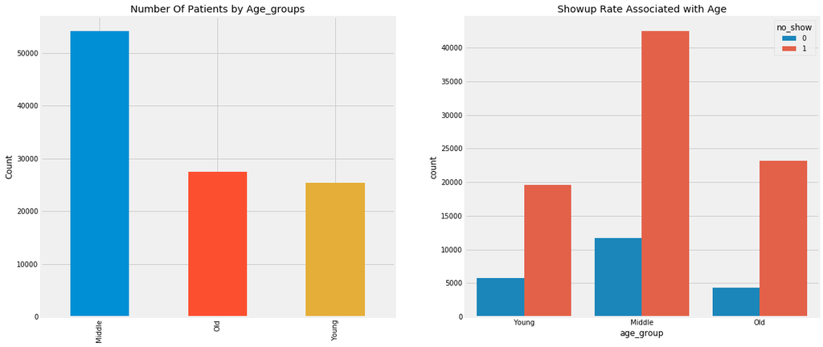

```python
# the show-up rate of elder patients is higher than other 2 groups, so we draw a bar chart to visualize the
# relationship between age and show up rate

f, ax = plt.subplots(1, 2, figsize=(18, 8))
df['age_group'].value_counts().plot.bar(ax=ax[0])
ax[0].set_title('Number Of Patients by Age_groups')
ax[0].set_ylabel('Count')
sns.countplot('age_group', hue='no_show', data=df, ax=ax[1])
ax[1].set_title('Showup Rate Associated with Age')
plt.show()
```

### 3. To investigate whether a patient is enrolled in Brasilian welfare program can affect his/her showup-rate:

```python
# calculate the show-up rate of whether the patient is on scholarship

scholarship = df.query('scholarship == 1')
no_scholars = df.query('scholarship == 0')
scholarship_no_show = scholarship['no_show'].mean()
no_scholarship_no_show = no_scholarship['no_show'].mean()

(scholarship_no_show, no_scholarship_no_show)
```

[output not shown]

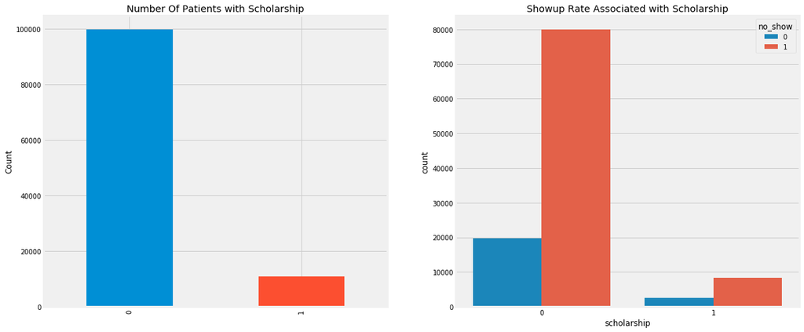

```python
# the show-up rate of patients without scholarship is higher, so we draw a bar chart to visualize the relationship
# between sholarship and show up rate.

f, ax = plt.subplots(1, 2, figsize=(18, 8))
df['scholarship'].value_counts().plot.bar(ax=ax[0])
ax[0].set_title('Number Of Patients with Scholarship')
ax[0].set_ylabel('Count')
sns.countplot('scholarship', hue='no_show', data=df, ax=ax[1])
ax[1].set_title('Showup Rate Associated with Scholarship')
plt.show()
```

### 4. To investigate whether a patient is an alcoholic can affect his/her showup-rate:

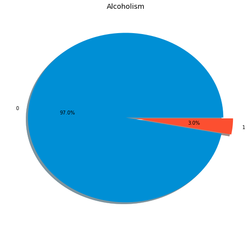

```python
# the pie chasrt shows rate of alcoholism

f,ax=plt.subplots(1,figsize=(8,8))
df['alcoholism'].value_counts().plot.pie(explode=[0,0.1],autopct='%1.1f%%',ax=ax,shadow=True)
ax.set_title('Alcoholism')
ax.set_ylabel('')
plt.show()
```

```python
# calculate the show-up rate of whether the patient is an alcoholic

alcoholism = df.query('alcoholism == 1')
non_alcoholism = df.query('alcoholism == 0')

alcoholism_no_show = alcoholism['no_show'].mean()
non_alcoholism_no_show = non_alcoholism['no_show'].mean()
(alcoholism_no_show, non_alcoholism_no_show)
```

```
(0.7985119047619048, 0.7980516208498964)
```

### Since the show-up rate of alcoholic and non-alcoholic appear to be very similar, I didn't follow this up with further visualization.

### 5. To investigate whether the appointment days can affect the showup-rates of patients:

```python
# add a new column to show which day of a week the appointmentday is
# load the first 2 rows to confirm the new column has been successfully added

df['weekday'] = df['appointmentday'].apply(lambda x: x.weekday())
df.head(2)
```

|  | patientid | appointmentid | gender | scheduledday | appointmentday | age | neighbourhood | scholarship | hipertension | diabetes | alcoholism | handcap | sms_received | no_show | age_group | weekday |
| --- | --- | --- | --- | --- | --- | --- | --- | --- | --- | --- | --- | --- | --- | --- | --- | --- |
| 0 | 2.987250e+13 | 5642903 | F | 2016-04-29 | 2016-04-29 | 62 | JARDIM DA PENHA | 0 | 1 | 0 | 0 | 0 | 0 | 1 | Old | 4 |
| 1 | 5.589978e+14 | 5642503 | M | 2016-04-29 | 2016-04-29 | 56 | JARDIM DA PENHA | 0 | 0 | 0 | 0 | 0 | 0 | 1 | Old | 4 |

[figure not shown]

```python
# gain information of the values of different days of a week

f, ax = plt.subplots(1,figsize=(8, 8))
df['weekday'].value_counts().plot.bar(ax=ax)
ax.set_title('Number Of Patients with Scholarship')
ax.set_ylabel('Count')
plt.show()
```

```python
# group the data according to whether the appointmentday is weekday or weekend
# calculate the show-up rate of whether appointment is on weekdays or weekends

weekday = df.query('weekday != 0')
weekend = df.query('weekday == 0')

weekday_no_show = weekday['no_show'].mean()
weekend_no_show = weekend['no_show'].mean()

(weekday_no_show, weekend_no_show)
```

```
(0.799241561517788, 0.7935194153385577)
```